# Ames Housing Data Study

2022-11-08

## Introduction

```r
library(dplyr)
library(tidyverse)
library(ggplot2)
library(glmnet)
library(plotmo)
set.seed(1)
train <- read_csv("train.csv")
test <- read_csv("test.csv")
```

## Exploratory Data Analysis

We start by exploring how sales price changes over time.

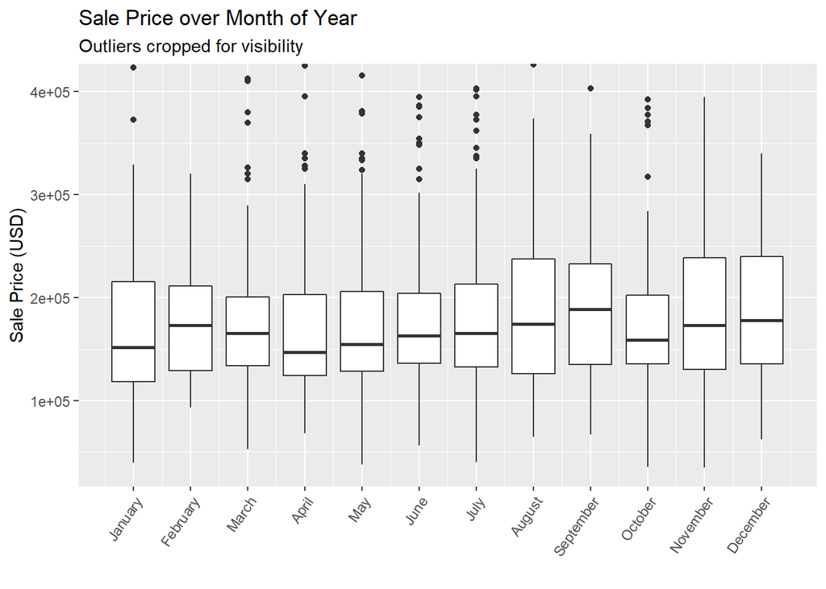

```r
#0 manually remove some problematic data points. Almost all NA values, outlier in saleprice
woc <- c(557, 1283, 1333)
train <- train[-woc,]

# 1.1 Trends in sales price over time by year, month
q1df <- train %>% dplyr::select(SalePrice, MoSold, YrSold, YearBuilt, OverallQual)
q1df$MoYr = as.POSIXct(paste(q1df$YrSold, q1df$MoSold, "1", sep="-"), format="%Y-%m-%d")
ylim1 = boxplot.stats(train$SalePrice)$stats[c(1, 5)]

q1df %>%
  ggplot(aes(x = MoSold, group = MoSold, y=SalePrice)) + geom_boxplot() +
  scale_x_continuous(
    breaks = seq_along(month.name),
    labels = month.name) +
  theme(axis.text.x = element_text(angle = 55, hjust = 1)) +
  coord_cartesian(ylim=c(ylim1[1], ylim1[2]*1.2)) +
  labs(title="Sale Price over Month of Year", x="", y="Sale Price (USD)", subtitle="Outliers cropped for visibility")
```

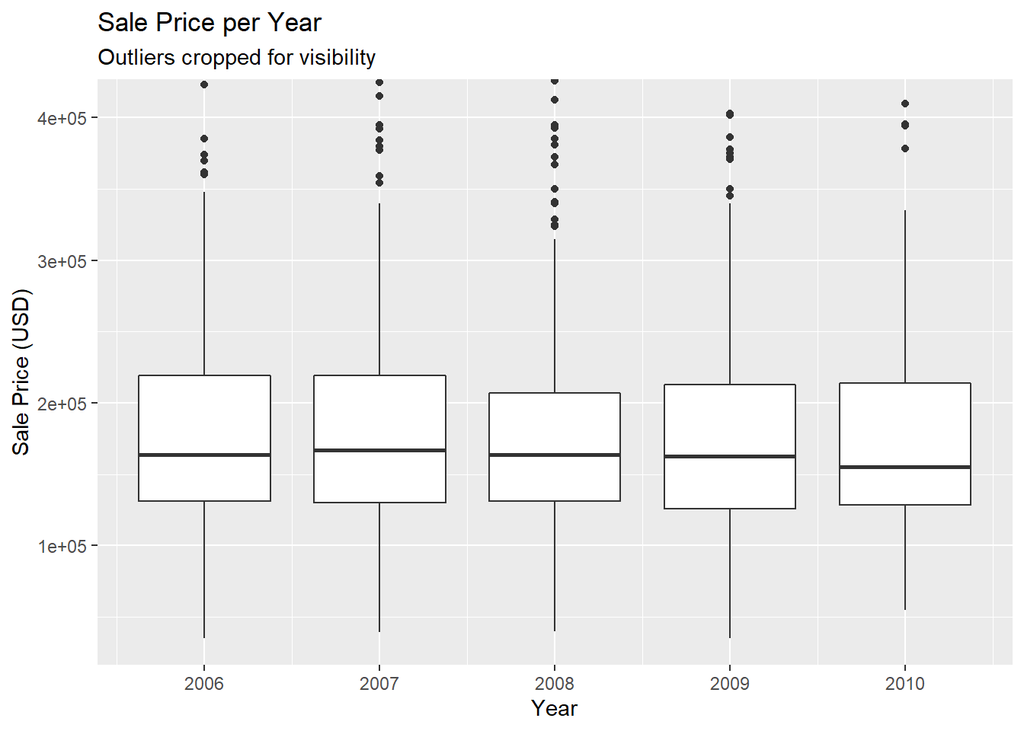

```r
q1df %>%
  ggplot(aes(x = YrSold, group = YrSold, y=SalePrice)) + geom_boxplot() +
  coord_cartesian(ylim=c(ylim1[1], ylim1[2]*1.2)) +
  labs(title="Sale Price per Year", x="Year", y="Sale Price (USD)", subtitle="Outliers cropped for visibility")
```

There doesn’t appear to be any notable relationship between year and sale price, other than a slight decrease over time.

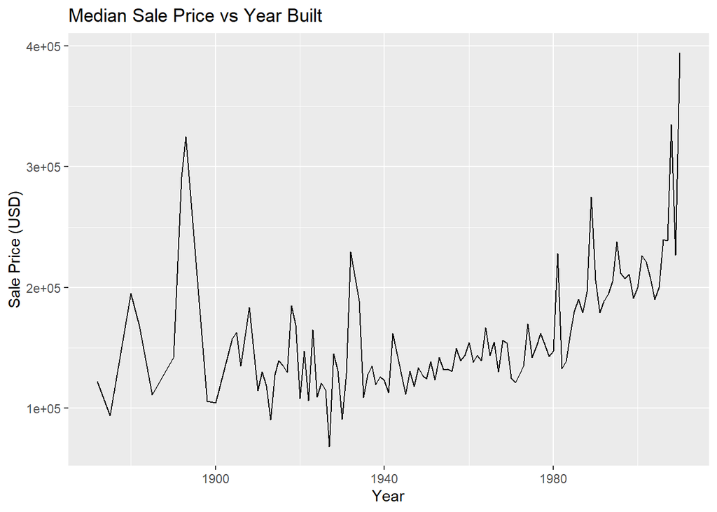

```r
#1.2 Sales Price vs Yr constructed
#at 217 there's an entry for a house built in... year 200... let's ignore that
q1df[-217,] %>% dplyr::select(YearBuilt, SalePrice) %>% group_by(YearBuilt) %>% summarize(medianSale=median(SalePrice)) %>%
  ggplot(aes(x=YearBuilt, y=medianSale)) + geom_line()+
  labs(title="Median Sale Price vs Year Built", x="Year", y="Sale Price (USD)")
```

The general trend for year built versus sale price is that houses that were built more recently sell for higher.

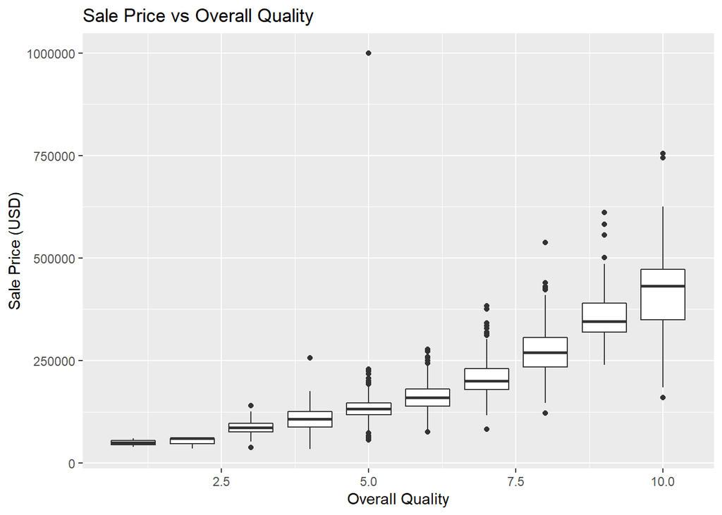

```r
#1.3 Sales Price vs Qual Index
q1df %>% ggplot(aes(x = OverallQual, group = OverallQual, y=SalePrice)) + geom_boxplot()+
  labs(title="Sale Price vs Overall Quality", x="Overall Quality", y="Sale Price (USD)")
```

We see a positive association between quality and sales price, which is to be expected.

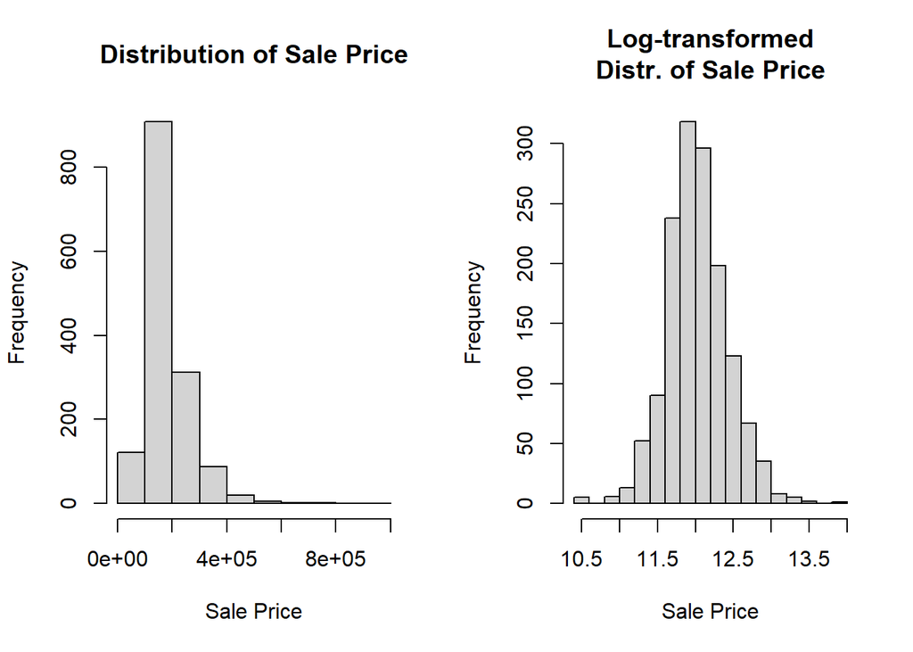

```r
#1.4 Distribution of SalesPrice
par(mfrow = c(1,2))
hist(q1df$SalePrice, main="Distribution of Sale Price", xlab="Sale Price")
hist(log(q1df$SalePrice), main="Log-transformed\nDistr. of Sale Price", xlab="Sale Price")
```

```r
shapiro.test(log(q1df$SalePrice))
```

```
##
##  Shapiro-Wilk normality test
##
## data:  log(q1df$SalePrice)
## W = 0.98988, p-value = 1.68e-08
```

## Neighborhood Value

One of the tasks assigned in the case was to select around three data proxies to be used to determine a neighborhood’s value for HIG. As HIG is a real-estate investment firm running a business, it would be within their interest to practice business where sales are happening frequently and profitably. Therefore some data proxies to track high value neighborhoods would include metrics such as number of sales made and median sale price in the last month. (Number of listings would also be considered, but in this database we only have listings for sold houses.)

We can also get a high-level look at what features may be associated with higher prices through correlation between sale price and numeric variables. Ordinal variables may also be considered, so those must be converted to numeric.

```r
#features
#according to the databook there's a number of ORDINAL CATEGORICAL VARIABLES
#e.g. level of quality: poor < fair < typical < good < excellent
train$Utilities <- recode(train$Utilities, "ELO" = 0, "NoSeWa" = 1, "NoSewr" = 2, "AllPub" = 3)
#...so forth
```

We observe that some variables, such as `Utilities`, are largely unhelpful since there is little variance within the variable:

```r
table(train$Utilities)
```

```
##
##    1    3
##    1 1456
```

Variables like these can interfere with our inference since self-evidently the one house with no running water in the entire dataset will sell for a much lower price, and we mistakenly think of `Utilities` as a highly correlated variable when it wouldn’t be very useful to see on a dashboard how every house except one has all public utilities. We remove such variables with near zero variation:

```r
#ignore unhelpful variables
#(i.e. variables that are mostly constant across rows anyway)
nzvMat <- caret::nearZeroVar(train, saveMetrics=T)
nzvNames <- row.names(nzvMat[nzvMat$nzv==T, ])
train <- train[ ,!nzvMat$nzv]
```

Then look at what some of the variables with high correlation with price are.

```r
ncol = dim(train)[2]
cor2sales <- train[, -ncol] %>% select_if(is.numeric) %>% cor(y=log(train[,ncol]), use="pairwise.complete.obs") %>% as.data.frame %>% tibble::rownames_to_column()
topByCor <- head(cor2sales[order(abs(cor2sales$SalePrice), decreasing=T),], 5)
topByCor
```

```
##        rowname SalePrice
## 6  OverallQual 0.8087544
## 23   GrLivArea 0.6973098
## 11   ExterQual 0.6717152
## 35  GarageCars 0.6668697
## 29 KitchenQual 0.6607320
```

```r
#train$CentralAir[is.na(train$CentralAir)] <- "N"
# I spent so much time on this and didn't even use it :0(
# train[sapply(train, is.character)] <- lapply(train[sapply(train, is.character)], as.factor)
# tmp.lm <- lm(log(SalePrice) ~. -Id -YrSold -MoSold -Neighborhood, data=train[, names(which(colSums(is.na(train)) == 0))])
# tmp.sum <- as.data.frame(summary(tmp.lm)$coefficients)
# tmp.sum <- as.data.frame(cbind(rownames(tmp.sum),tmp.sum[,"Pr(>|t|)"]))
# colnames(tmp.sum) <- c("coefficient", "pval")
# tmp.sum$pval <- as.numeric(tmp.sum$pval)
# tmp.coeffs <- tmp.sum[which(tmp.sum$pval < 0.05),]
# tmp.coeffs[order(tmp.coeffs$pval),]
```

Features like Overall Quality, above-ground living area, and garage space appear to associate strongly with price, so we can include these metrics in a neighborhood value view.

Based on these proposed proxies, we can find the top three neighborhoods at a given year and month. Since HIG wants to focus on neighborhoods with increasing prices and high volume of sales, we will choose the three neighborhoods with the highest increases in median sales price and with a higher-than-median number of sales made.

```r
#manually picked July 2006 for having most data pts
tmp1 <- train %>% filter(MoSold == 6, YrSold == 2006) %>% group_by(Neighborhood) %>% summarize(medSale = median(SalePrice))
medSaleChangeMonth <- train %>% filter(MoSold == 7, YrSold == 2006) %>% group_by(Neighborhood) %>% summarize(medSale = median(SalePrice))
medSaleChangeMonth = medSaleChangeMonth$medSale - tmp1$medSale
myNeighborhoods <- train %>% filter(MoSold == 7, YrSold == 2006) %>% group_by(Neighborhood) %>% summarize(totalSales = n(), medOveralQ = median(OverallQual), medGarageCars = median(GarageCars), medGrLvArea=median(GrLivArea)) %>% cbind(medSaleChangeMonth) %>% arrange(desc(medSaleChangeMonth))
myNeighborhoods %>% filter(totalSales > median(totalSales), medSaleChangeMonth > 0) %>% .[1:3,]
```

```
##   Neighborhood totalSales medOveralQ medGarageCars medGrLvArea
## 1      NoRidge          4        8.0           2.5      2279.0
## 2       Sawyer          5        5.0           2.0      1721.0
## 3      Gilbert          4        6.5           2.0      1673.5
##   medSaleChangeMonth
## 1             125000
## 2              50000
## 3              49820
```

The data is from the month and year of July 2006, when the most monthly sales were made in the data. The top 3 neighborhoods would be as displayed above.

## Modeling and Diagnostics

Our initial model will be a linear model that uses every variable to predict SalePrice. This model does not use all 80 variables, we used `nearZeroVar` to reduce the number of columns considered.

```r
dim(train)
```

```
## [1] 1457   60
```

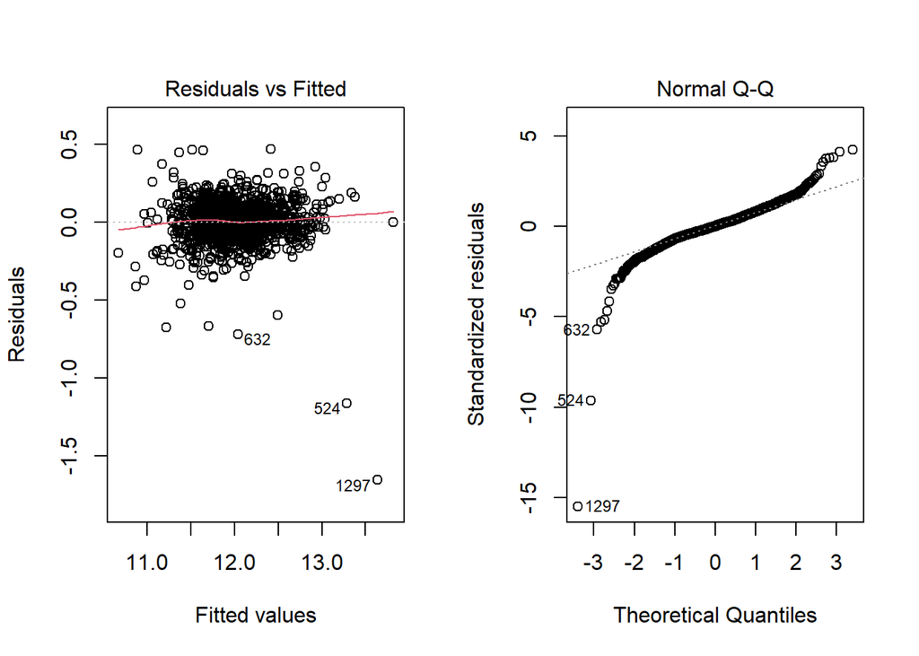

```r
#linear model
train.md <- subset(train, select=-c(Id))
train.md <- train.md[, names(which(colSums(is.na(train.md)) == 0))]
my.cols = names(train.md)
names(train.md) <- make.names(names(train.md))
my.lm <- lm(log(SalePrice) ~., data=train.md)
lm.rmse = sqrt(mean((my.lm$residuals)^2))
linear.error = data.frame(RMSE = lm.rmse, Rsquared = summary(my.lm)$r.squared)

par(mfrow=c(1,2))
plot(my.lm, which=c(1,2))
```

We check if the linear model adheres to linear regression assumptions of linearity, constant variance, independence, and normality with the residual and Q-Q plots. The residuals appear normally distributed, centered around zero, and have no relationship to the fitted values. The Q-Q plot shows that the distribution has more extreme values than would be seen from a true normal distribution, but the points largely fall on a straight line so can be considered acceptably normal.

The RMSE and R-squared values of this linear model are below:

```r
linear.error
```

```
##        RMSE  Rsquared
## 1 0.1253243 0.9028047
```

Our RMSE is quite low and our R-squared is high – on average, this linear model’s predictions were close to the actual values, and about 90% of variability in the response data (SalesPrice) is explained by the model. Based on these metrics, the linear model is performing well.

However, this is likely a case of overfitting on the training data, since we are using so many explanatory variables to predict SalesPrice. The objective of the study is to predict future sale prices with unseen data. One way to solve this problem is through regularization. We first try fitting a ridge regression model to the data, using 10-fold cross validation and lambda values ranging from $10^{2}$ to $10^{-3}$:

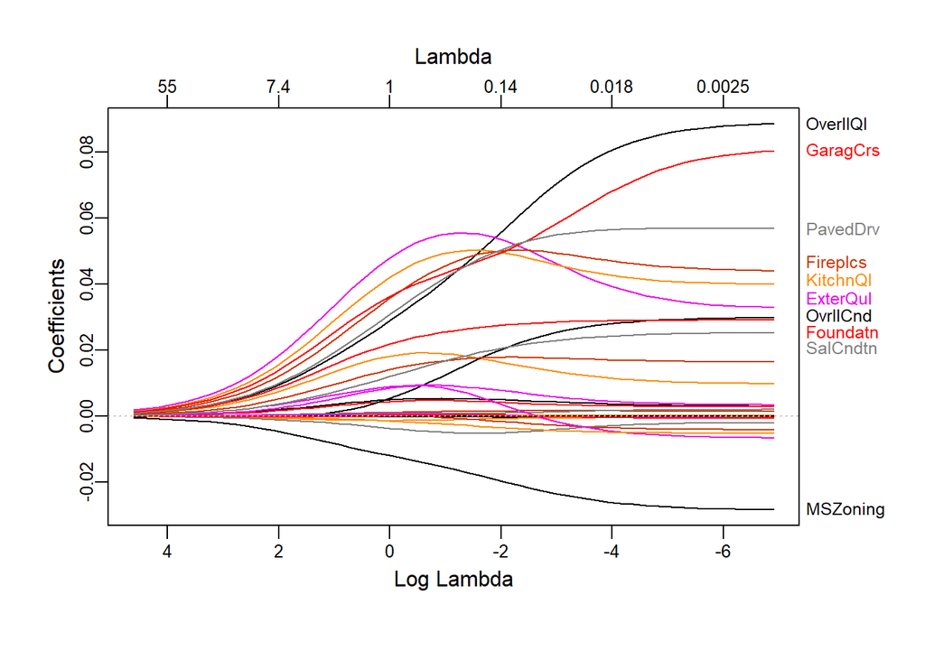

```r
#something that isnt just a linear model
y = log(train.md$SalePrice)
x <- subset(train.md, select=-c(SalePrice)) %>% data.matrix
#ridge
lam.list = 10^seq(2, -3, by = -.1)
cv_ridge <- cv.glmnet(x, y, alpha=0, lambda=lam.list)
#cv_ridge$lambda.min
plot_glmnet(cv_ridge$glmnet.fit)
```

We can loosely interpret some of the relationships between variables using the GLM ridge regression plot. For example, MSZoning is one of the first variables to enter the model (that is, its coefficient value leaves 0) and stays as a variable with a high coefficient value. We see that ExteriorQual’s coefficient value increases, then decreases as OverallQual increases, which we can attribute to the two variables having colinearity, as a property with high exterior quality would have high overall quality.

The error metrics of the ridge regression are below.

```r
ridge.trainerror <- predict(cv_ridge, newx=x, s = "lambda.min") %>% caret::postResample(., y)
ridge.trainerror
```

```
##      RMSE  Rsquared       MAE
## 0.1658390 0.8345860 0.1031762
```

The ridge regression’s RMSE and R-squared are worse than the linear model, but this is to be expected since the idea behind ridge regression is to penalize overfitting coefficients, so its training error may be worse than the linear model.

We can also try fitting a lasso regression. Since coefficient values can be reduced to 0 in lasso regression, it can give us a better idea of which features may be more significant while also avoiding overfitting like ridge regression by yielding simpler models with fewer coefficients.

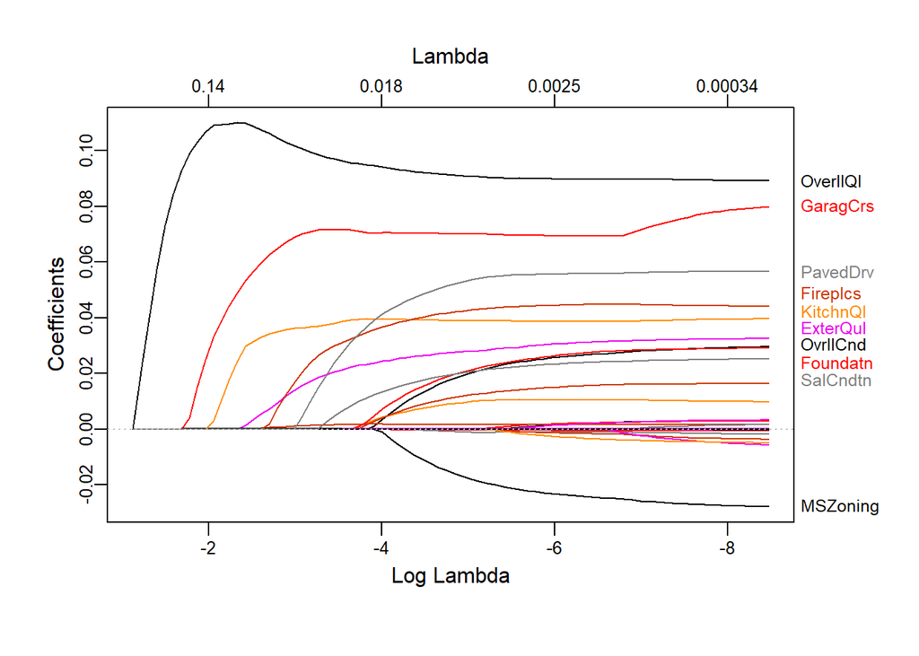

```r
#lasso
out = glmnet(x, y)
cvfit = cv.glmnet(x, y, alpha=1,nfolds=10)
#coef(cvfit, s="lambda.min")
plot_glmnet(cvfit$glmnet.fit)
```

The order of magnitude of coefficients remain the same from ridge regression, although the values and paths taken are different, and the total number of coefficients remaining at the end is smaller in the lasso regression. We can also see the order of variables entering the model more clearly.

```r
lasso.trainerror <- predict(cvfit, newx=x, s = "lambda.min") %>% caret::postResample(., y)
lasso.trainerror
```

```
##      RMSE  Rsquared       MAE
## 0.1780432 0.8154295 0.1186117
```

The training error on the lasso regression is slightly worse than the ridge regression, but this is expected behavior as the lasso is a simpler model.

Choosing one of the models becomes a matter of deciding between the risk of overfitting or underfitting (the bias-variance tradeoff). In this particular case, we want to be able to apply the model to future data and in other regions, so we choose to use the lasso regression despite its higher training error.

## Results

We can rank feature significance by finding their order of entry into the lasso regression model. More important features enter the model earlier.

```r
first_nonzero = function(x){
                  if(any(x!=0)){
                     min(which(x!=0))
                  }else{
                     length(x)
                }
}
j=which(cvfit$glmnet.fit$lambda == cvfit$lambda.min)
tmp = cvfit$glmnet.fit$beta[,1:j]
coef(cvfit, s="lambda.min")[names(sort(apply(tmp, 1, first_nonzero))),] %>% subset(.!=0)
```

```
##   OverallQual     GrLivArea    GarageCars     X1stFlrSF   KitchenQual
##  9.706347e-02  1.642077e-04  7.152027e-02  5.900802e-05  3.810176e-02
##     ExterQual   TotalBsmtSF  YearRemodAdd    Fireplaces    BsmtFinSF1
##  2.055547e-02  2.194164e-05  1.566731e-03  2.978917e-02  3.685760e-05
##    PavedDrive SaleCondition       LotArea    WoodDeckSF
##  2.362869e-02  4.667749e-03  3.895008e-07  2.434157e-05
```

The above vector shows the variables and their coefficients in their order of entry into the model. Here, the top five features would be Overall Quality, square feet of above-ground living area, garage capacity, square feet of the first floor, and kitchen quality.

Using our model, the ten houses with the highest predicted prices are

```r
#there's a value at ind 1256 where the year is 20003 instead of 2003
test$YearBuilt[1256] = 2003
test$YearRemodAdd[1256] = 2003
my.cols = my.cols[1:length(my.cols)-1]
idk = predict(cvfit, newx=data.matrix(test[,my.cols]), s="lambda.min")
test.pred = data.frame(Id=test$Id, exp(idk))
colnames(test.pred) = c("Id", "SalePrice")
test.pred[order(test.pred$SalePrice, decreasing=T)[1:10],]
```

```
##        Id SalePrice
## 1090 2550  920238.9
## 204  1664  466088.0
## 515  1975  438759.4
## 511  1971  431387.6
## 1169 2629  427105.2
## 218  1678  420345.6
## 20   1480  409675.3
## 1171 2631  409219.4
## 835  2295  404130.9
## 833  2293  403416.4
```

## Conclusions and Future Work

Using lasso regularized regression, we were able to create a model with RMSE of approximately $0.178$ and R-squared of $0.815$ to predict the sales prices of properties from the test data. We can rank feature importance by the order of their entry into the regression model during lasso regularization. Unfortunately post-selection inference goes beyond the scope of this case and so more rigorous tests of coefficients’ statistical significance will yet to be explored.

Likely the greatest pitfall of the model is that it fails to acknowledge the three most important elements of real estate, those being location, location, and location. This is especially egregious considering that we want to be able to apply the model to other locations. Since the extent of locational information in the given dataset was mostly limited to nominal variables about the property’s zoning classification or not varied enough to contribute to the model, it may be helpful to have quantitative information such as a property’s latitude, longitude, and elevation, which are easier variables to mathematically model. Even just with the data given, the lasso regression may be underfit, considering that its error was worst among the three models considered, and more complex modeling techniques such as elastic net regression or non-linear regression could have been better picks. Finally, there may be some ethical considerations given that one of the highest-contributing features of the model is Overall Quality, which is a heuristic measurement by local realtors who are not immune to bias; [racial discrimination in housing appraisals is a well-documented phenomenon.](https://www.nytimes.com/2022/11/02/realestate/racial-bias-home-appraisals.html)